# Plant Microbiome Metaanalysis

Joe Edwards

## Load in the libraries

Note that this analysis relies on the tidyMB package. This can be found on my github profile.

```r
library(vegan)
library(broom)
library(tidyverse)
library(broom)
library(biobroom)
library(tidyMB)
library(DESeq2)
```

```r
## Do Not Run
# wExp <- read_rds("~/RMB/SoilDomesticationData/wExp.rds")
# wExp %>%
  # filter(!Experiment%in%c("Mix", "Transplant", "Weeds")) %>%
  # ungroup() %>%
  # group_by(variable) %>%
  # filter(sum(value) > 0) %>%
  # dplyr::select(-From, - Site, -LatinName, -host_subject_id) %>%
  # saveRDS("~/RMB/SoilDomestication/Data/ma_data.rds") %>%
  filter(!Compartment%in%c("fresh water", "Grapes", "Leaves", "Rhizoplane"))
```

[output not shown]

```
Gathering metadata
Removing the column variable from the metadata.
```

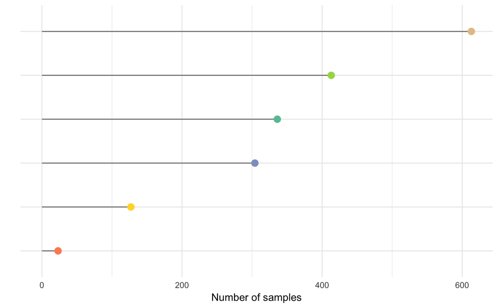

```r
mExp %>%
  grab_metadata(.) %>%
  dplyr::count(study) %>%
  mutate(study_order = fct_reorder(study, n)) %>%
  ggplot(aes(n, fct_reorder(study_order, n), color = study)) +
  geom_segment(aes(x = 0, xend = n, y = study_order, yend = study_order), color = "gray50") +
  geom_point(size = 3) +
  scale_color_manual(values = c(brewer.pal(7, "Set2")[-4])) +
  theme_minimal() +
  labs(x = "Number of samples", y ="") +
  theme(axis.text.y = element_blank(), legend.position = "none")
```

```r
plant_cap <- tidy_cap(mExp %>% ungroup() %>% mutate(logRA = log2(RA * 1000 + 1)), value = "logRA", formula = "host_common_name")
```

```
Gathering metadata
Removing the column variable from the metadata.
Converting to wide table.
```

```r
plant_pcoa <-  tidy_pcoa(mExp %>% ungroup() %>% mutate(logRA = log2(RA * 1000 + 1)), value = "logRA")
```

```
Gathering metadata
Removing the column variable from the metadata.
Converting to wide table.
```

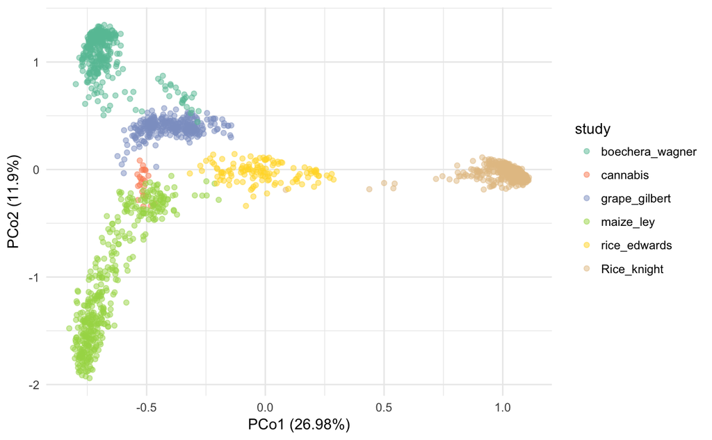

```r
mAdon %>% tidy()
```

```
The following column names in ANOVA output were not recognized or transformed: SumsOfSqs, MeanSqs, F.Model, R2
```

| term | df | SumsOfSqs | MeanSqs | F.Model | R2 | p.value |
| --- | --- | --- | --- | --- | --- | --- |
| Compartment | 8 | 278.34060 | 34.7925752 | 238.3812 | 0.4531166 | 0.001 |
| study | 4 | 72.78541 | 18.1963528 | 124.6722 | 0.1184889 | 0.001 |
| Residuals | 1803 | 263.15424 | 0.1459535 | NA | 0.4283944 | NA |
| Total | 1815 | 614.28026 | NA | NA | 1.0000000 | NA |

## Alpha diversity

Honestly, I hate this part. I really don’t see the need for this analysis. What does it mean? What does it matter, espcieally given that different metrics give different results? Sigh… Here we go anyway. I guess.

```r
mAdiv <- mExp %>%
  filter(RA > 0) %>%
  ungroup() %>%
  group_by(Compartment, host_common_name, study, SampleID, depth) %>%
  summarise(richness = sum(RA > 0), shannon = -sum(log2(RA) * RA))
```

Let’s plot out the results

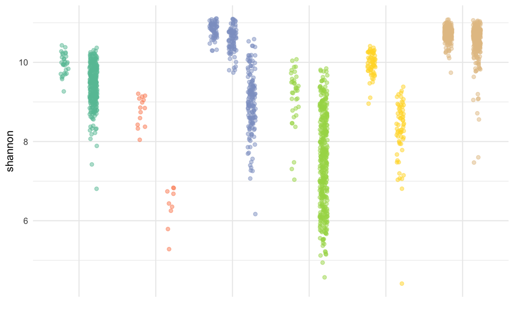

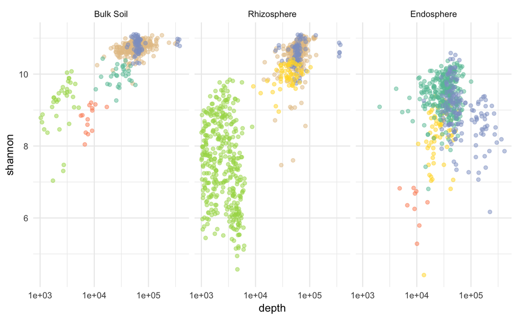

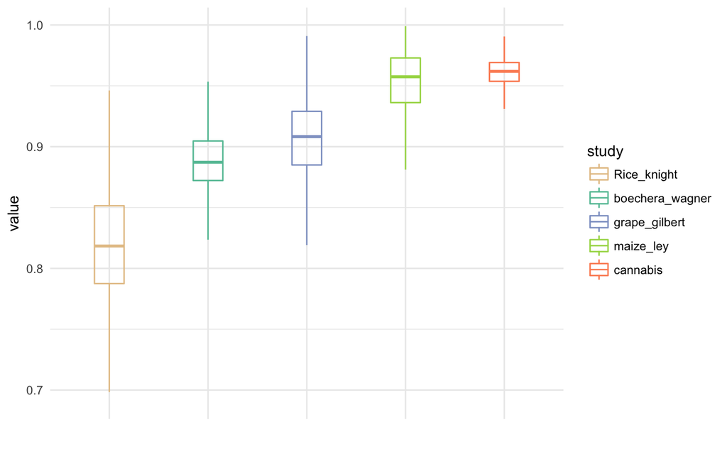

| term | estimate | std.error | statistic | p.value |
| --- | --- | --- | --- | --- |
| (Intercept) | 0.81839088 | 0.0001654632 | 4946.0595 | 0 |
| studyboechera_wagner | 0.07037435 | 0.0002334280 | 301.4821 | 0 |
| studygrape_gilbert | 0.08763910 | 0.0002491124 | 351.8055 | 0 |
| studymaize_ley | 0.13331636 | 0.0002223844 | 599.4861 | 0 |
| studycannabis | 0.14299295 | 0.0009757810 | 146.5420 | 0 |

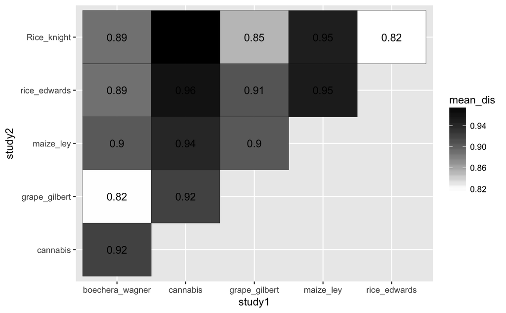

## Phylum level analysis

Let’s aggregate the counts at the phylum level and give it a go.

```r
mPhy <- mExp %>%
  inner_join(tax, by = "variable") %>%
  group_by(SampleID, Compartment, Phylum2, host_common_name, study) %>%
  summarise(sample_total = sum(RA)) %>% ungroup() %>%
  mutate(Compartment = ifelse(grepl("soil", Compartment, ignore.case = T), "Bulk Soil", Compartment)) %>%
  mutate(Compartment = ifelse(grepl("rhizosphere", Compartment, ignore.case = T), "Rhizosphere", Compartment)) %>%
  mutate(Compartment = ifelse(grepl("root", Compartment, ignore.case = T), "Endosphere", Compartment)) %>%
  filter(!Compartment%in%c("fresh water", "Grapes", "Leaves", "Rhizoplane"))
```

Next, let’s ask the question: which phyla are consistently enriched or depleted in the rice studies compared to the other studies. The way we will go about doing this is to fit each OTU to two different models. One where the rice_edwards dataset is the reference and the other with rice_knight being the reference. Then find the phyla that behave consistently between the two models.

```r
rice_ed <- mPhy %>%
  mutate(study = relevel(factor(study), ref = "rice_edwards")) %>%
  filter(study != "Rice_knight") %>%
  group_by(Phylum2) %>%
  nest() %>%
  mutate(model = map(data, ~lm(log2(sample_total * 1000 + 1) ~ study, .))) %>%
  unnest(map(model, ~tidy(.))) %>%
  filter(term != "(Intercept)") %>%
  mutate(p.adj = p.adjust(p.value, "BH")) %>%
  filter(p.adj <= 0.05) %>%
  mutate(direction = ifelse(estimate > 0, "other", "rice")) %>%
  mutate(model = "rice_ed")
rice_kn <- mPhy %>%
  mutate(study = relevel(factor(study), ref = "Rice_knight")) %>%
  filter(study != "rice_edwards") %>%
  group_by(Phylum2) %>%
  nest() %>%
  mutate(model = map(data, ~lm(log2(sample_total * 1000 + 1) ~ study, .))) %>%
  unnest(map(model, ~tidy(.))) %>%
  filter(term != "(Intercept)") %>%
  mutate(p.adj = p.adjust(p.value, "BH")) %>%
  filter(p.adj <= 0.05) %>%
  mutate(direction = ifelse(estimate > 0, "other", "rice")) %>%
  mutate(model = "rice_kn")
```

Now that we have the two models, let’s stick em together, filter out the phyla that are consistent between the models, and then identify the phyla that are enriched or depleted in rice compared to every other dataset.

| direction | Phylum2 | nn | total |
| --- | --- | --- | --- |
| other | Gammaproteobacteria | 4 | 282.50697027 |
| other | Bacteroidetes | 4 | 200.09203870 |
| rice | Deltaproteobacteria | 4 | 178.07640166 |
| rice | Chloroflexi | 4 | 64.61137915 |
| rice | Chlorobi | 4 | 17.84364067 |
| rice | Euryarchaeota | 4 | 13.91114570 |
| rice | Spirochaetes | 4 | 7.57224479 |
| rice | Armatimonadetes | 4 | 6.24288580 |
| rice | Cyanobacteria | 4 | 5.33314332 |
| rice | NC10 | 4 | 2.49473421 |

[output cut: 15 more lines]